# Homework #3

Braedon Giblin

1. Find the average years of education for the respondents with each marital status. Arrange your output in a meaningful order and print.

   Answer:

   ```r
   dat <- dat %>%
     mutate("Marital status" = factor(`Marital status`, c("Married", "Separated", "Divorced", "Widowed", "Never married", "No answer")),
            "General happiness" = factor(`General happiness`, c("Very happy", "Pretty happy", "Not too happy", "Not applicable", "Don't know", "No answer")))
   dat %>%
     group_by(`Marital status`) %>%
     summarise_at(vars("Highest year of school completed"), list(name = mean))
   ```

   ```
   ## # A tibble: 6 x 2
   ##   `Marital status`  name
   ## * <fct>            <dbl>
   ## 1 Married           13.5
   ## 2 Separated         12.6
   ## 3 Divorced          13.5
   ## 4 Widowed           12.4
   ## 5 Never married     13.8
   ## 6 No answer         15.4
   ```

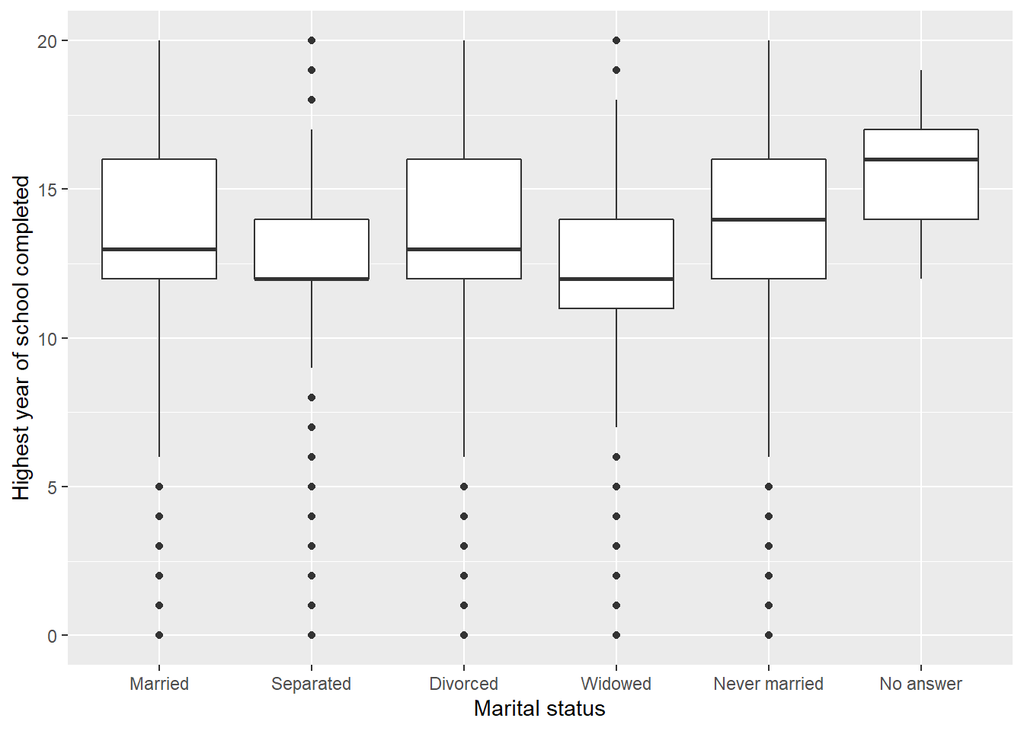

   ```r
   ggplot(data = dat, aes_string(x = "`Marital status`", y = "`Highest year of school completed`")) + geom_boxplot()
   ```

   Widowed and separated people seem to have the least education. Widowed is logical because most widowed people are probably older, and older people had lower educational standards.
2. Create a single data frame containing records for the better educated respondents with each marital status. A “better educated” respondent is someone who has strictly more years of education than the average among those with the same marital status. Print the structure of the data frame.

   Answer:

   ```r
   b <- dat %>%
     group_by(`Marital status`) %>%
     mutate(avg_edu = mean(`Highest year of school completed`))
   b %>%
     filter(`Highest year of school completed` > avg_edu) %>%
     ungroup %>%
     select(-avg_edu) %>%
     str
   ```

   ```
   ## tibble [17,624 x 10] (S3: tbl_df/tbl/data.frame)
   ##  $ Gss year for this respondent    : num [1:17624] 1973 1973 1973 1973 1973 ...
   ##  $ General happiness               : Factor w/ 6 levels "Very happy","Pretty happy",..: 2 1 1 2 3 2 2 1 1 1 ...
   ##  $ Political party affiliation     : chr [1:17624] "Not str democrat" "Ind,near rep" "Other party" "Strong republican" ...
   ##  $ Respondents sex                 : chr [1:17624] "Male" "Male" "Male" "Male" ...
   ##  $ Highest year of school completed: num [1:17624] 16 16 16 16 16 18 16 16 19 17 ...
   ##  $ Marital status                  : Factor w/ 6 levels "Married","Separated",..: 5 1 1 1 1 1 5 1 1 1 ...
   ##  $ Number of hours worked last week: num [1:17624] 35 40 42 40 23 55 50 60 60 40 ...
   ##  $ Labor force status              : chr [1:17624] "Working fulltime" "Working fulltime" "Working fulltime" "Working fulltime" ...
   ##  $ Respondent id number            : num [1:17624] 8 10 35 36 37 45 47 48 57 58 ...
   ##  $ Ballot used for interview       : chr [1:17624] "Not applicable" "Not applicable" "Not applicable" "Not applicable" ...
   ```

3. How is the happiness of a respondent related to his/her marriage status? Define that a person is happy if the response to question is “Very happy” or “Pretty happy”.

   Answer:

   round(prop.table(table(dat$`Marital status`, dat$happy), 1) * 100)
   ```

   ```
   ##
   ##                 FALSE TRUE
   ##   Married          13   87
   ##   Separated        28   72
   ##   Divorced         23   77
   ##   Widowed          23   77
   ##   Never married    20   80
   ##   No answer        22   78
   ```

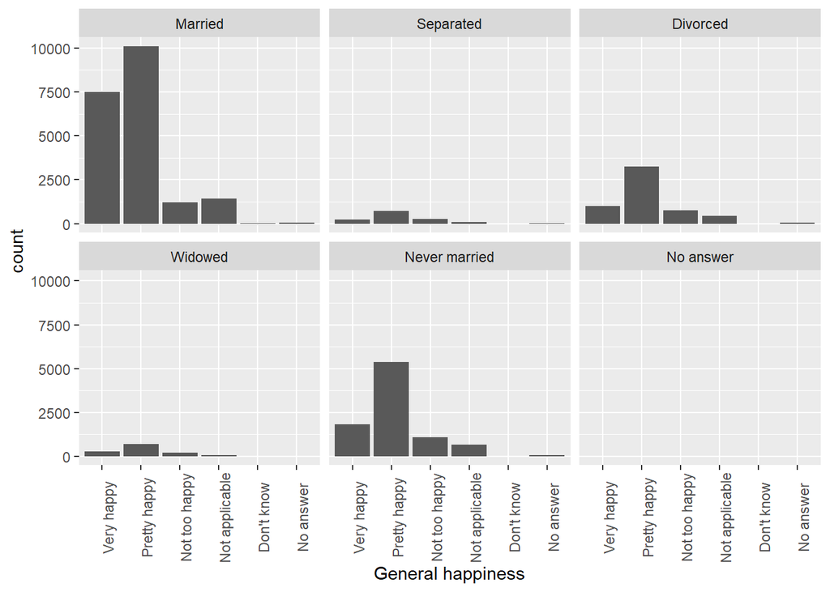

   ```r
   dat %>%
    ggplot(aes(x=`General happiness`)) + geom_bar() + facet_wrap(~ `Marital status`) + theme(axis.text.x = element_text(angle = 90))
   ```

   In General, married people seem the most happy. The table above shows the percentage of people in each marital state that are happy. From the table, seperated people are among the least happy.while married is the most happy. The other states are fairly even.
4. Does party affiliation affect the relationship you found in the last question?

   Answer:

   ```r
   round(prop.table(table(dat$`Marital status`, dat$`Political party affiliation`, dat$happy), 1) * 100)
   ```

   ```
   ## , ,  = FALSE
   ##
   ##
   ##                 Don't know Ind,near dem Ind,near rep Independent No answer
   ##   Married                0            2            1           3         0
   ##   Separated              0            3            2           6         0
   ##   Divorced               0            3            2           4         0
   ##   Widowed                0            3            1           4         0
   ##   Never married          0            3            2           4         0
   ##   No answer              0            0            0           0        11
   ##
   ##                 Not str democrat Not str republican Other party Strong democrat
   ##   Married                      2                  2           0               2
   ##   Separated                    7                  3           0               4
   ##   Divorced                     5                  3           1               4
   ##   Widowed                      5                  3           0               6
   ##   Never married                4                  2           1               3
   ##   No answer                   11                  0           0               0
   ##
   ##                 Strong republican
   ##   Married                       2
   ##   Separated                     2
   ##   Divorced                      2
   ##   Widowed                       2
   ##   Never married                 1
   ##   No answer                     0
   ##
   ## , ,  = TRUE
   ##
   ##
   ##                 Don't know Ind,near dem Ind,near rep Independent No answer
   ##   Married                0           10            9          12         0
   ##   Separated              0            9            6          13         0
   ##   Divorced               0           10            8          12         0
   ##   Widowed                0            9            6          10         0
   ##   Never married          0           13            8          13         0
   ##   No answer              0           11            0          22         0
   ##
   ##                 Not str democrat Not str republican Other party Strong democrat
   ##   Married                     17                 16           1              11
   ##   Separated                   15                  9           1              15
   ##   Divorced                    15                 12           1              12
   ##   Widowed                     17                 12           1              16
   ##   Never married               17                 11           2              11
   ##   No answer                    0                 22          11               0
   ##
   ##                 Strong republican
   ##   Married                      10
   ##   Separated                     3
   ##   Divorced                      6
   ##   Widowed                       7
   ##   Never married                 5
   ##   No answer                    11
   ```

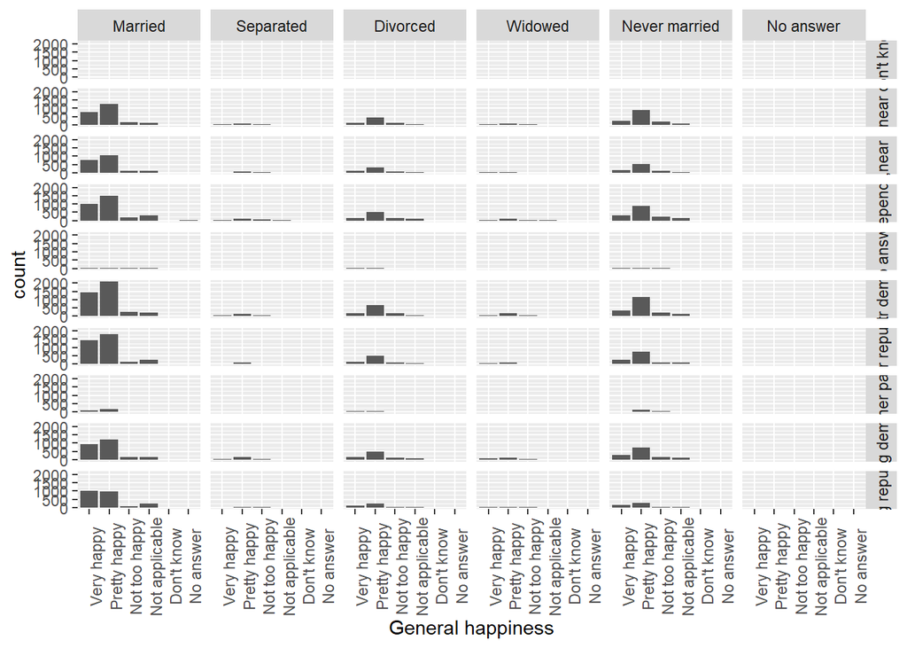

   ```r
   dat %>%
     ggplot(aes(x=`General happiness`)) + geom_bar() + facet_grid(`Political party affiliation` ~ `Marital status`) + theme(axis.text.x = element_text(angle = 90), strip.text.y = element_text(angle = 90))
   ```

   Using the above table and plots, it appears that independents are among the least happy. Not strong democrats and not strong repubicans are happier, irrelevant of marital status.
5. How is marrital status related to the education of a respondent? What are possible reasons accounting for the patterns you see?

   Answer:

   ```r
   dat <- dat %>%
     mutate("Marital status" = factor(`Marital status`, c("Married", "Separated", "Divorced", "Widowed", "Never married", "No answer")),
            "General happiness" = factor(`General happiness`, c("Very happy", "Pretty happy", "Not too happy", "Not applicable", "Don't know", "No answer")))
   dat %>%
     group_by(`Marital status`) %>%
     summarise_at(vars("Highest year of school completed"), list(name = mean))
   ```

   ```
   ## # A tibble: 6 x 2
   ##   `Marital status`  name
   ## * <fct>            <dbl>
   ## 1 Married           13.5
   ## 2 Separated         12.6
   ## 3 Divorced          13.5
   ## 4 Widowed           12.4
   ## 5 Never married     13.8
   ## 6 No answer         15.4
   ```

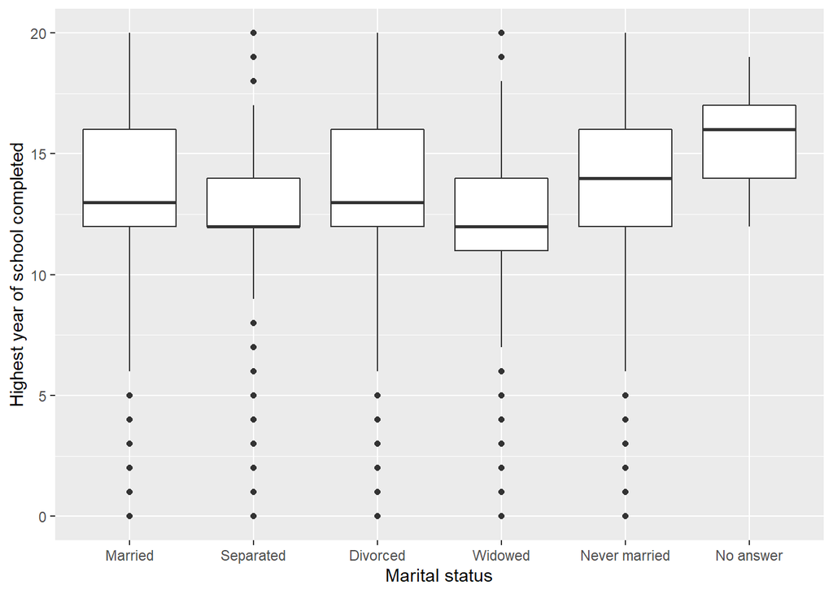

   ```r
   ggplot(data = dat, aes_string(x = "`Marital status`", y = "`Highest year of school completed`")) + geom_boxplot()
   ```

   Answer: Question 1. How does the hours worked last week correspond to education level?

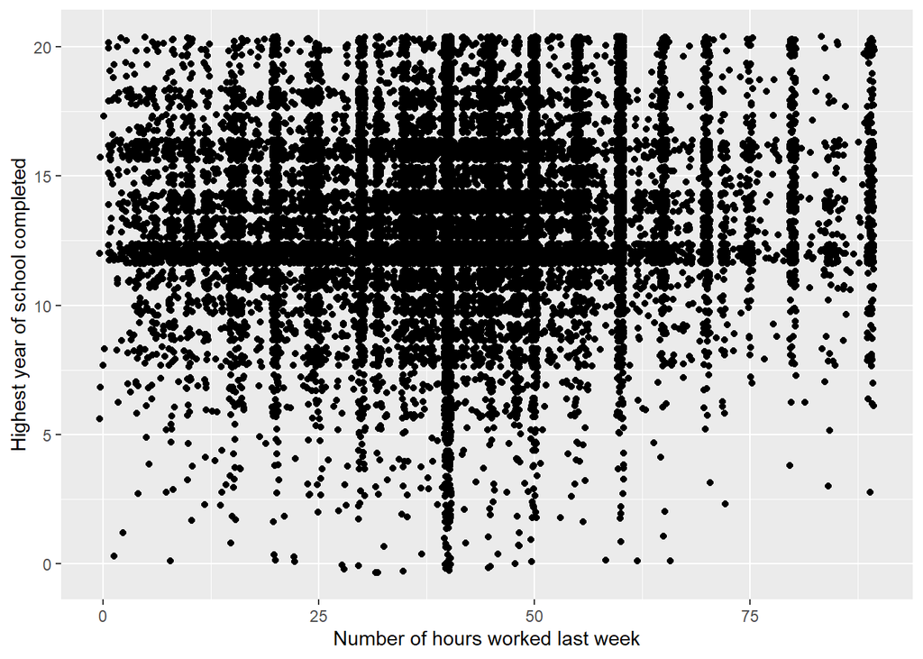

   ```r
   dat %>%
     ggplot(aes(x = `Number of hours worked last week`, y = `Highest year of school completed`)) + geom_jitter()
   ```

   ```r
   print("Works more than 40 hours a week: ")
   ```

   ```
   ## [1] "Works more than 40 hours a week: "
   ```

   ```r
   dat  %>%
     filter(`Number of hours worked last week` > 40) %>%
     summarise(mean_rate = mean(`Highest year of school completed`, na.rm=TRUE),
         sd_rate = sd(`Highest year of school completed`, na.rm=TRUE),)
   ```

   ```
   ## # A tibble: 1 x 2
   ##   mean_rate sd_rate
   ##       <dbl>   <dbl>
   ## 1      13.9    2.95
   ```

   ```r
   print("Works less than or equal to 40 hours a week: ")
   ```

   ```
   ## [1] "Works less than or equal to 40 hours a week: "
   ```

   ```r
   dat  %>%
     filter(`Number of hours worked last week` <= 40) %>%
     summarise(mean_rate = mean(`Highest year of school completed`, na.rm=TRUE),
         sd_rate = sd(`Highest year of school completed`, na.rm=TRUE),)
   ```

   ```
   ## # A tibble: 1 x 2
   ##   mean_rate sd_rate
   ##       <dbl>   <dbl>
   ## 1      13.3    2.87
   ```

   Most people seem to work around 40 hours a week regardless of education. However, looking at the average education for people who work more than 40 hours a week and comparring to the education of people who work less than or equal to 40 hours a week, it can be seen that slightly higher education levels are present among those who work more. This is intersesting as it implies that more education does not equal an easier workload.

   Question 2. How does work per week effect happiness?

   ```r
   dat %>%
     group_by(`General happiness`) %>%
     summarise_at(vars("Number of hours worked last week"), list(name = mean))
   ```

   ```
   ## # A tibble: 6 x 2
   ##   `General happiness`  name
   ## * <fct>               <dbl>
   ## 1 Very happy           41.5
   ## 2 Pretty happy         41.3
   ## 3 Not too happy        40.0
   ## 4 Not applicable       42.0
   ## 5 Don't know           45.6
   ## 6 No answer            42.9
   ```

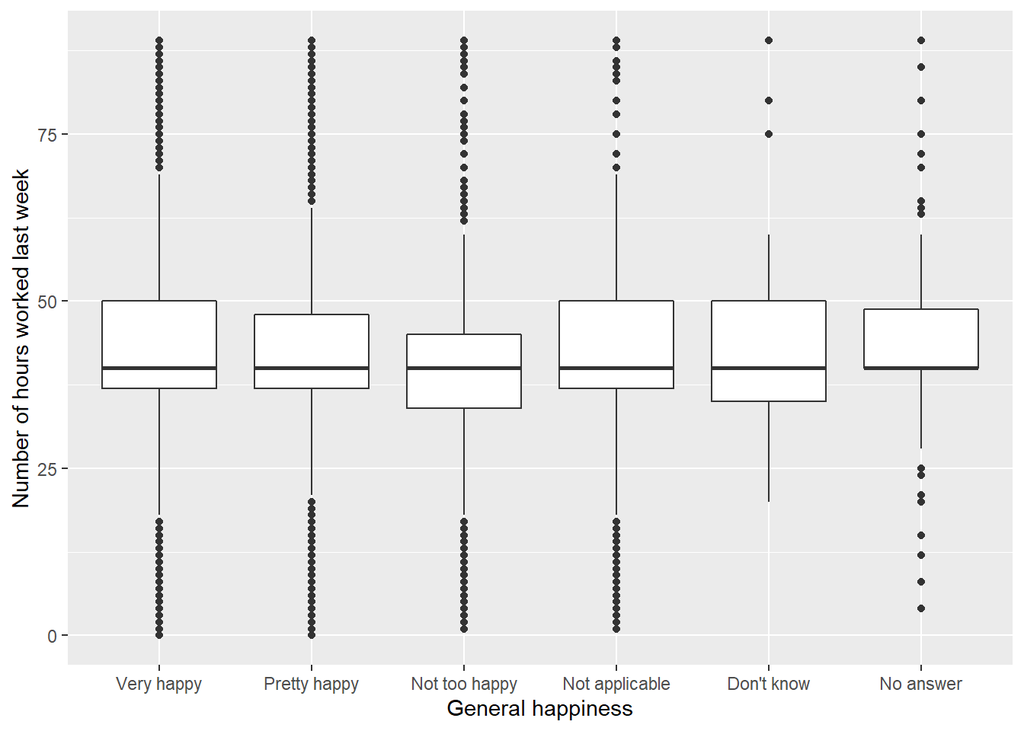

   ```r
   ggplot(data = dat, aes(x = `General happiness`, y = `Number of hours worked last week`)) + geom_boxplot()
   ```

   Work hours seem to have very little impact on happiness. However, happy people seem to work slightly more than not too happy people. This could perhaps be because they earn more money by working longer.